# Japan Unemployment predictions

## Importing dataset:

```r
rm(list=ls())
data_japan=read.csv("Japan_Unemployment.csv")
head(data_japan)
```

```
##      TIME Unemployment_Rate Employment_Rate_15_64 Working_Age_Population_15_64
## 1 1975-11             0.021              0.659374                     75654440
## 2 1975-12             0.021              0.659842                     75747382
## 3 1976-01             0.021              0.661498                     75797614
## 4 1976-02             0.020              0.662158                     75767387
## 5 1976-03             0.020              0.662846                     75839650
## 6 1976-04             0.021              0.659644                     75934952
##   Labour_Force_15_64 Economic_Inactivity_Rates_15_64 Unemployed_Males
## 1           51010000                        0.326014           740000
## 2           50550000                        0.323541           800000
## 3           49820000                        0.324121           800000
## 4           49910000                        0.324116           720000
## 5           50830000                        0.323705           730000
## 6           51390000                        0.326397           770000
##   Unemployed_Females Unemployed_all  CPI
## 1             370000        1100000 54.7
## 2             340000        1140000 54.7
## 3             330000        1130000 55.7
## 4             370000        1090000 56.1
## 5             320000        1050000 56.3
## 6             340000        1110000 57.6
```

```r
tail(data_japan)
```

```
##        TIME Unemployment_Rate Employment_Rate_15_64
## 564 2022-10             0.026              0.786715
## 565 2022-11             0.025              0.784647
## 566 2022-12             0.025              0.785700
## 567 2023-01             0.024              0.787192
## 568 2023-02             0.026              0.783979
## 569 2023-03             0.028              0.782000
##     Working_Age_Population_15_64 Labour_Force_15_64
## 564                     74003919           59970000
## 565                     73829426           59500000
## 566                     73844960           59550000
## 567                     73832099           59360000
## 568                     73586132           59110000
## 569                     73930000           59580000
##     Economic_Inactivity_Rates_15_64 Unemployed_Males Unemployed_Females
## 564                        0.191664          1070000             710000
## 565                        0.193953          1040000             690000
## 566                        0.193039          1030000             680000
## 567                        0.192086          1000000             670000
## 568                        0.193870          1080000             710000
## 569                        0.194000          1150000             800000
##     Unemployed_all   CPI
## 564        1780000 103.7
## 565        1730000 103.9
## 566        1710000 104.1
## 567        1670000 104.7
## 568        1800000 104.0
## 569        1950000 104.4
```

#### Data of Labour force from 2011-03 to 2011-08 were missing due to earthquake. For these months approximate value has been put there based on the participation rate during that year.

## Feature Scaling - Creating a new variable:

```r
data_japan$male_to_female_unemp=round((data_japan$Unemployed_Males/data_japan$Unemployed_Females),4)
print(data_japan$male_to_female_unemp[1:10])
```

```
##  [1] 2.0000 2.3529 2.4242 1.9459 2.2812 2.2647 2.2647 2.1471 2.2727 2.1471
```

#### This is to incorporate the factor - whether female are getting more unemployed or not compared to males over the years - as an external variable for overall unemployment rate.

## Checking Multicollinearity using VIFs:

```r
suppressWarnings(library(regclass))
VIF(lm(formula = Unemployment_Rate ~ Employment_Rate_15_64+Working_Age_Population_15_64+Labour_Force_15_64+Economic_Inactivity_Rates_15_64+Unemployed_all+CPI+male_to_female_unemp, data = data_japan))
```

```
##           Employment_Rate_15_64    Working_Age_Population_15_64
##                     13066.90798                        53.90800
##              Labour_Force_15_64 Economic_Inactivity_Rates_15_64
##                        38.32807                     15137.06140
##                  Unemployed_all                             CPI
##                       907.96954                        35.93361
##            male_to_female_unemp
##                         3.84045
```

### Removing Economic_Inactivity_Rates_15_64:

```r
VIF(lm(formula = Unemployment_Rate ~ Employment_Rate_15_64+Working_Age_Population_15_64+Labour_Force_15_64+Unemployed_all+CPI+male_to_female_unemp, data = data_japan))
```

```
##        Employment_Rate_15_64 Working_Age_Population_15_64
##                    43.252975                    41.809405
##           Labour_Force_15_64               Unemployed_all
##                    38.071781                     6.499345
##                          CPI         male_to_female_unemp
##                    34.340895                     3.755630
```

### Removing Employment_Rate_15_64:

```r
VIF(lm(formula = Unemployment_Rate ~ Working_Age_Population_15_64+Labour_Force_15_64+Unemployed_all+CPI+male_to_female_unemp, data = data_japan))
```

```
## Working_Age_Population_15_64           Labour_Force_15_64
##                     6.612017                    21.955752
##               Unemployed_all                          CPI
##                     2.995417                    20.483774
##         male_to_female_unemp
##                     3.571736
```

### Removing Labour_Force_15_64:

```r
VIF(lm(formula = Unemployment_Rate ~ Working_Age_Population_15_64+Unemployed_all+CPI+male_to_female_unemp, data = data_japan))
```

```
## Working_Age_Population_15_64               Unemployed_all
##                     1.633869                     2.975656
##                          CPI         male_to_female_unemp
##                     4.360960                     3.223064
```

### This is the final set of variables free from multicollinearity.

## Train-Test split of the dataset - last 6 months of the data would be taken into testing part:

```r
df_japan_train1=data_japan[1:(nrow(data_japan)-6),]
df_japan_test1=data_japan[(nrow(data_japan)-5):nrow(data_japan),]
head(df_japan_train1)
```

```
##      TIME Unemployment_Rate Employment_Rate_15_64 Working_Age_Population_15_64
## 1 1975-11             0.021              0.659374                     75654440
## 2 1975-12             0.021              0.659842                     75747382
## 3 1976-01             0.021              0.661498                     75797614
## 4 1976-02             0.020              0.662158                     75767387
## 5 1976-03             0.020              0.662846                     75839650
## 6 1976-04             0.021              0.659644                     75934952
##   Labour_Force_15_64 Economic_Inactivity_Rates_15_64 Unemployed_Males
## 1           51010000                        0.326014           740000
## 2           50550000                        0.323541           800000
## 3           49820000                        0.324121           800000
## 4           49910000                        0.324116           720000
## 5           50830000                        0.323705           730000
## 6           51390000                        0.326397           770000
##   Unemployed_Females Unemployed_all  CPI male_to_female_unemp
## 1             370000        1100000 54.7               2.0000
## 2             340000        1140000 54.7               2.3529
## 3             330000        1130000 55.7               2.4242
## 4             370000        1090000 56.1               1.9459
## 5             320000        1050000 56.3               2.2812
## 6             340000        1110000 57.6               2.2647
```

- The model would be trained on the train dataset.
- And the performance of the fitted model would be checked on the test dataset.
- If this performs fairly well, this model would be considered to get the future forecasts.

## Time series plot:

```r
suppressWarnings(library(fpp2))
```

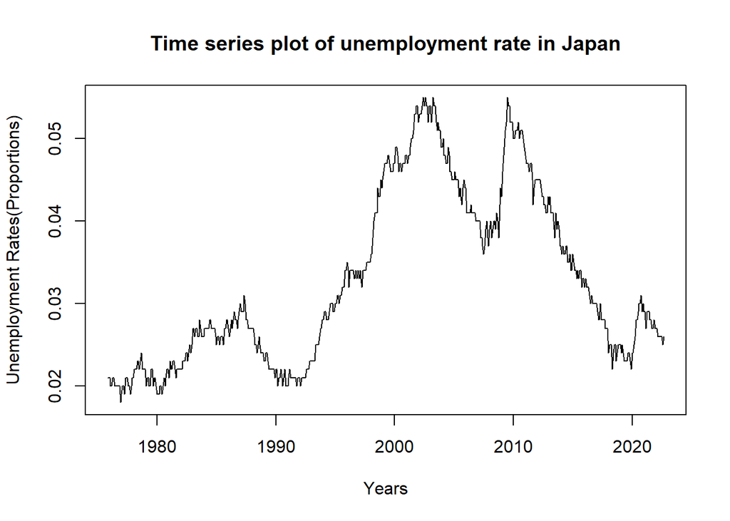

```r
suppressWarnings(library(urca))
df.ts=ts(df_japan_train1$Unemployment_Rate, frequency = 12, start = c(1975,11))
plot(df.ts,xlab="Years",ylab="Unemployment Rates(Proportions)")
title(main="Time series plot of unemployment rate in Japan")
```

## Testing stationarity:

```r
df_japan_train1[,"Unemployment_Rate"] %>%
  ur.kpss() %>%
  summary()
```

```
##
## #######################
## # KPSS Unit Root Test #
## #######################
##
## Test is of type: mu with 6 lags.
##
## Value of test-statistic is: 3.152
##
## Critical value for a significance level of:
##                 10pct  5pct 2.5pct  1pct
## critical values 0.347 0.463  0.574 0.739
```

#### This series is non-stationary - 1st order differencing would be necessary.

## Testing stationarity after 1st order differencing:

```r
diff(df_japan_train1[,"Unemployment_Rate"]) %>%
  ur.kpss() %>%
  summary()
```

```
##
## #######################
## # KPSS Unit Root Test #
## #######################
##
## Test is of type: mu with 6 lags.
##
## Value of test-statistic is: 0.363
##
## Critical value for a significance level of:
##                 10pct  5pct 2.5pct  1pct
## critical values 0.347 0.463  0.574 0.739
```

#### The 1st order differences can be said to be stationary at 5% level of significance.

## ACF plot:

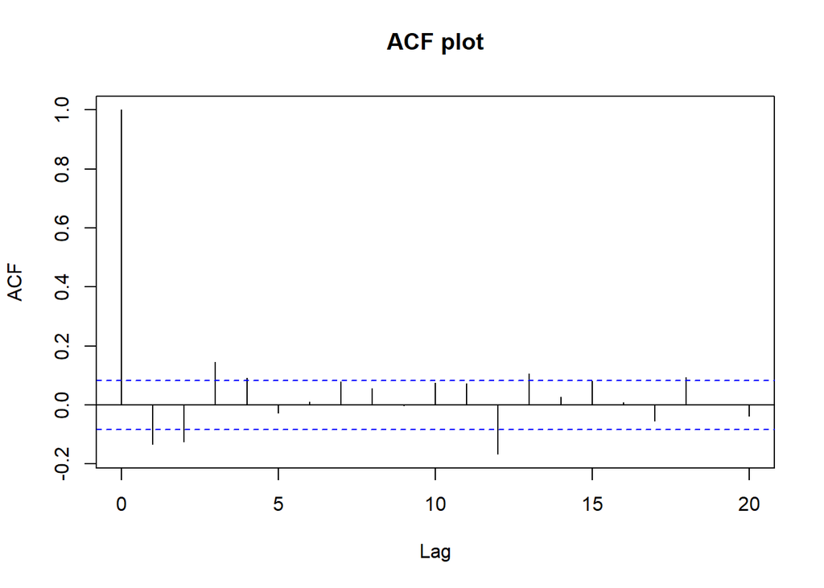

```r
par(mfrow=c(1,1))
acf(diff(df_japan_train1$Unemployment_Rate), lag.max = 20, main = "ACF plot")
```

#### p=0/1/2/3, based on the no. of significant lags.

## PACF plot:

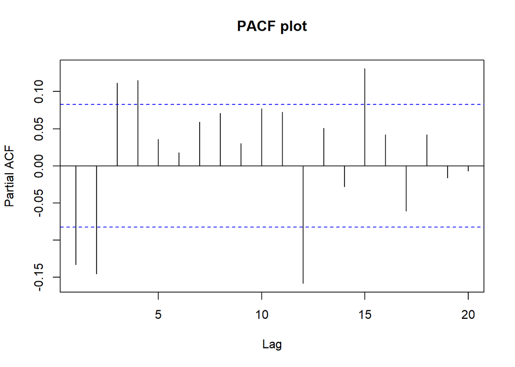

```r
par(mfrow=c(1,1))
pacf(diff(df_japan_train1$Unemployment_Rate), lag.max = 20, main = "PACF plot")
```

#### q=0/1/2/3/4, based on the no. of significant lags.

## Fitting ARIMAX model ignoring the variables that were eliminated due to high VIF:

### Starting with the value of p & q as 3 & 4 respectively with the rest of the regressors:

```r
est_train=arima(df_japan_train1$Unemployment_Rate, order=c(3,1,4), xreg = as.matrix(df_japan_train1[,c(4,9,10,11)]), method = "ML")
summary(est_train)
```

```
##
## Call:
## arima(x = df_japan_train1$Unemployment_Rate, order = c(3, 1, 4), xreg = as.matrix(df_japan_train1[,
##     c(4, 9, 10, 11)]), method = "ML")
##
## Coefficients:
```

```
##           ar1      ar2     ar3      ma1     ma2      ma3     ma4
##       -0.3987  -0.1169  0.1735  -0.3173  -0.249  -0.2492  0.1409
## s.e.      NaN      NaN     NaN      NaN     NaN   0.0487     NaN
##       Working_Age_Population_15_64  Unemployed_all  CPI  male_to_female_unemp
##                                  0               0    0                 1e-04
## s.e.                           NaN             NaN    0                 2e-04
##
## sigma^2 estimated as 1.041e-07:  log likelihood = 3719.99,  aic = -7415.98
##
## Training set error measures:
##                         ME         RMSE          MAE       MPE      MAPE
## Training set -3.189237e-05 0.0003223791 0.0002686316 -0.129861 0.9110315
##                   MASE        ACF1
## Training set 0.3620406 -0.01475248
```

### Test of significance of individual coefficients:

```r
suppressWarnings(library(lmtest))
coeftest(est_train)
```

```
##
## z test of coefficients:
##
##                                 Estimate  Std. Error z value  Pr(>|z|)
## ar1                          -3.9867e-01         NaN     NaN       NaN
## ar2                          -1.1686e-01         NaN     NaN       NaN
## ar3                           1.7354e-01         NaN     NaN       NaN
## ma1                          -3.1732e-01         NaN     NaN       NaN
## ma2                          -2.4897e-01         NaN     NaN       NaN
## ma3                          -2.4916e-01  4.8692e-02 -5.1170 3.104e-07 ***
## ma4                           1.4091e-01         NaN     NaN       NaN
## Working_Age_Population_15_64 -1.6996e-10         NaN     NaN       NaN
## Unemployed_all                1.5128e-08         NaN     NaN       NaN
## CPI                          -2.7653e-05  2.5209e-05 -1.0970    0.2727
## male_to_female_unemp          6.1606e-05  1.6440e-04  0.3747    0.7079
## ---
## Signif. codes:  0 '***' 0.001 '**' 0.01 '*' 0.05 '.' 0.1 ' ' 1
```

#### After removing the variables producing NaNs & the insignificant variables one by one, the final model results are:

```r
est_2=arima(df_japan_train1$Unemployment_Rate, order=c(2,1,1), method = "ML")
summary(est_2)
```

```
##
## Call:
## arima(x = df_japan_train1$Unemployment_Rate, order = c(2, 1, 1), method = "ML")
##
## Coefficients:
##           ar1      ar2     ma1
##       -0.4377  -0.1918  0.2921
## s.e.   0.1685   0.0436  0.1687
##
## sigma^2 estimated as 1.05e-06:  log likelihood = 3070.86,  aic = -6133.71
##
## Training set error measures:
##                        ME        RMSE          MAE         MPE     MAPE
## Training set 1.097945e-05 0.001023989 0.0007720725 -0.01822717 2.471948
##                  MASE        ACF1
## Training set 1.040539 0.005877635
```

### Test of significance of coefficients:

```r
suppressWarnings(library(lmtest))
coeftest(est_2)
```

```
##
## z test of coefficients:
##
##      Estimate Std. Error z value  Pr(>|z|)
## ar1 -0.437677   0.168526 -2.5971  0.009402 **
## ar2 -0.191840   0.043626 -4.3973 1.096e-05 ***
## ma1  0.292116   0.168749  1.7311  0.083440 .
## ---
## Signif. codes:  0 '***' 0.001 '**' 0.01 '*' 0.05 '.' 0.1 ' ' 1
```

## Plot of Fitted vs Original values for train dataset:

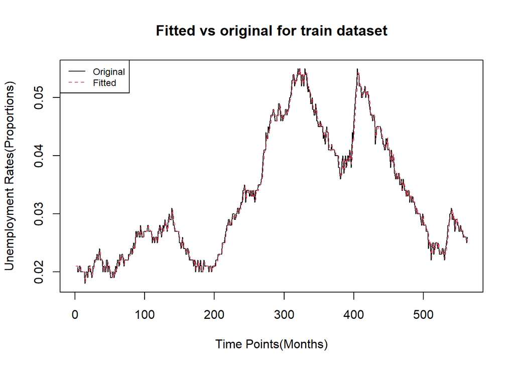

```r
res2=residuals(est_2)
data_fit2=df_japan_train1$Unemployment_Rate-res2
ts.plot(df_japan_train1$Unemployment_Rate, type="l", xlab="Time Points(Months)", ylab="Unemployment Rates(Proportions)", main="Fitted vs original for train dataset")
points(data_fit2, type="l", col=2, lty=2)
legend("topleft",c("Original","Fitted"), col=c(1,2), lty=c(1,2), cex=0.75)
```

## Predictions of unemployment rates for the test dataset using the above fitted model:

```r
test_pred2=predict(est_2, n.ahead=6, se.fit=FALSE, method="ML")
```

### Predicted values:

```r
print(as.vector(test_pred2))
```

```
## [1] 0.02600345 0.02581010 0.02589406 0.02589441 0.02587815 0.02588520
```

### Original values:

```r
print(df_japan_test1$Unemployment_Rate)
```

```
## [1] 0.026 0.025 0.025 0.024 0.026 0.028
```

## Performane on test dataset:

#### MAPE (in %):

```r
(1/length(df_japan_test1$Unemployment_Rate))*(sum(abs(df_japan_test1$Unemployment_Rate-as.vector(test_pred2))/abs(df_japan_test1$Unemployment_Rate)))*100
```

```
## [1] 3.790801
```

#### RMSE:

```r
sqrt(mean((df_japan_test1$Unemployment_Rate-as.vector(test_pred2))^2))
```

```
## [1] 0.001260399
```

#### Thus we can say that the final model we had chosen is working well, more or less, for future datasets.

## Now using this model, we would fit the actual data of Japan from Nov, 1975 to March, 2023 & obtain forecast for April.

### Checking stationarity:

```r
data_japan[,"Unemployment_Rate"] %>%
  ur.kpss() %>%
  summary()
```

```
##
## #######################
## # KPSS Unit Root Test #
## #######################
##
## Test is of type: mu with 6 lags.
##
## Value of test-statistic is: 3.0511
##
## Critical value for a significance level of:
##                 10pct  5pct 2.5pct  1pct
## critical values 0.347 0.463  0.574 0.739
```

```r
diff(data_japan[,"Unemployment_Rate"]) %>%
  ur.kpss() %>%
  summary()
```

```
##
## #######################
## # KPSS Unit Root Test #
## #######################
##
## Test is of type: mu with 6 lags.
##
## Value of test-statistic is: 0.3141
##
## Critical value for a significance level of:
##                 10pct  5pct 2.5pct  1pct
## critical values 0.347 0.463  0.574 0.739
```

### ACF plot:

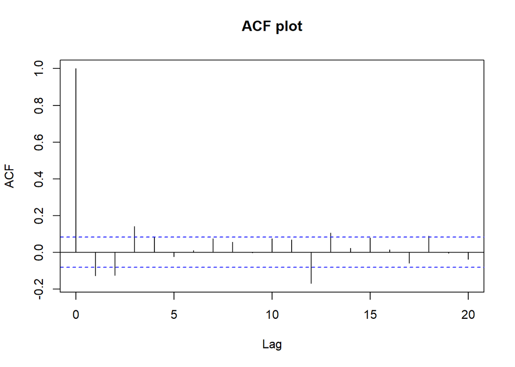

```r
par(mfrow=c(1,1))
acf(diff(data_japan$Unemployment_Rate), lag.max = 20, main = "ACF plot")
```

### PACF plot:

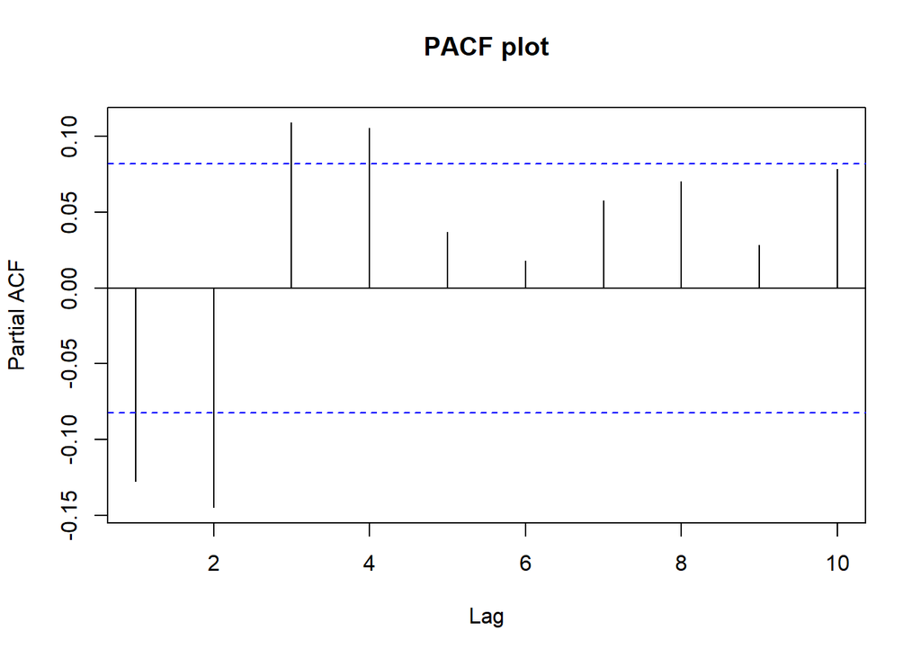

```r
par(mfrow=c(1,1))
pacf(diff(data_japan$Unemployment_Rate), lag.max = 10, main = "PACF plot")
```

## Fitting the model:

```r
est_3=arima(data_japan$Unemployment_Rate, order=c(2,1,1), method = "ML")
summary(est_3)
```

```
##
## Call:
## arima(x = data_japan$Unemployment_Rate, order = c(2, 1, 1), method = "ML")
##
## Coefficients:
##           ar1      ar2     ma1
##       -0.4380  -0.1932  0.2965
## s.e.   0.1701   0.0434  0.1706
##
## sigma^2 estimated as 1.057e-06:  log likelihood = 3101.85,  aic = -6195.69
##
## Training set error measures:
##                        ME        RMSE          MAE          MPE     MAPE
## Training set 1.413312e-05 0.001027239 0.0007748223 -0.007266005 2.487642
##                  MASE        ACF1
## Training set 1.040423 0.005446084
```

### Test of significance of individual coefficients:

```r
suppressWarnings(library(lmtest))
coeftest(est_3)
```

```
##
## z test of coefficients:
##
##      Estimate Std. Error z value  Pr(>|z|)
## ar1 -0.438002   0.170148 -2.5742   0.01005 *
## ar2 -0.193180   0.043404 -4.4507 8.558e-06 ***
## ma1  0.296510   0.170577  1.7383   0.08216 .
## ---
## Signif. codes:  0 '***' 0.001 '**' 0.01 '*' 0.05 '.' 0.1 ' ' 1
```

## Plot of Fitted vs Original on the actual data:

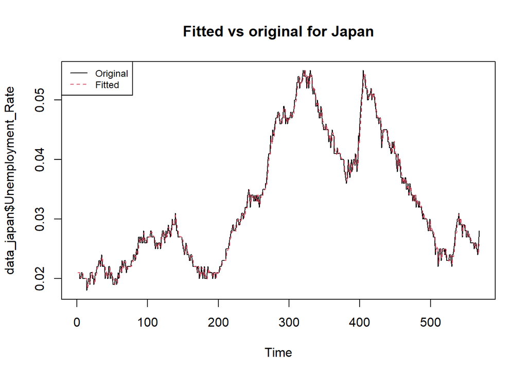

```r
res=residuals(est_3)
data_fit=data_japan$Unemployment_Rate-res
ts.plot(data_japan$Unemployment_Rate, type="l", main="Fitted vs original for Japan")
points(data_fit, type="l", col=2, lty=2)
legend("topleft",c("Original","Fitted"), col=c(1,2), lty=c(1,2), cex=0.75)
```

## Getting April forecast:

```r
future_unemp_pred=predict(est_3, n.ahead=1, se.fit=FALSE, method="ML")
print(future_unemp_pred)
```

```
## Time Series:
## Start = 570
## End = 570
## Frequency = 1
## [1] 0.02736623
```

## Upper & Lower limits (95% C.I.s):

```r
upper=as.vector(future_unemp_pred)+(1.96*(sqrt(est_3$sigma2)))
lower=as.vector(future_unemp_pred)-(1.96*(sqrt(est_3$sigma2)))
```

## Upper limit for April 2023 forecast:

```r
print(as.vector(upper))
```

```
## [1] 0.02938139
```

## Lower limit for April 2023 forecast:

```r
print(as.vector(lower))
```

```
## [1] 0.02535107
```

### April 23 forecast - 2.74 %

### Upper & Lower limits - (2.535 %, 2.938 %)